# Увод в иконометрията

## Упражнение 1 (03.10.2023)

### Задача 1

Хвърляме правилна монета 3 пъти. Намерете разпределението на сл.в. X, брой паднали се гербове. Намерете очакването и дисперсията на X.

```r
x <- 0:3
prob <- c(1/8, 3/8 , 3/8, 1/8)

mu <- sum(x * prob)
sigma2 <- sum((x - mu)^2 * prob)

print(mu)
```

```
## [1] 1.5
```

```r
print(sigma2)
```

```
## [1] 0.75
```

```r
# cumulative distribution function
F <- cumsum(prob)
print(F)
```

```
## [1] 0.125 0.500 0.875 1.000
```

### Биномно разпределение

```r
# dbinom -> P(X = x), X in Bi(size, prob)
print(dbinom(x=2, size=10, prob=1/3))
```

```
## [1] 0.1950922
```

```r
# pbinom -> P(X <= q), X in Bi(size, prob)
print(pbinom(q=2, size=3, prob=1/2))
```

```
## [1] 0.875
```

```r
# pbinom -> 1 - P(X <= q), X in Bi(size, prob)
print(pbinom(q=2, size=3, prob=1/2, lower.tail=F))
```

```
## [1] 0.125
```

```r
# qbinom -> pbinom^(-1)
print(qbinom(p=0.875, size=3, prob=1/2))
```

```
## [1] 2
```

```r
# rbinom -> sample Bi(size, prob)
print(rbinom(n=5, size=10, prob=1/2))
```

```
## [1] 4 2 8 6 4
```

### Задача 2

Малка фабрика произвежда крушки, които биват тествани преди опаковането и доставката. Служителите не могат да тестват всички крушки и затова проверяват една на сто произведени за час. Установили, че в произведените за един час има 2% неработещи, но въпреки това изпратили крушките за продажба. Като продавач се притеснявате за качеството на тези крушки, които продавате по една. Ако клиент си купи 20 крушки, каква е вероятността, че всичките ще работят?

```r
# X in Bi(20, 0.98)
print(dbinom(x=20, size=20, prob=0.98))
```

```
## [1] 0.667608
```

```r
mean <- 20 * 0.98
print(mean)
```

```
## [1] 19.6
```

```r
x <- c(0:20)
prob <- dbinom(x=x, size=20, prob=0.98)
print(prob)
```

```
##  [1] 1.048576e-34 1.027604e-31 4.783499e-29 1.406349e-26 2.928721e-24
##  [6] 4.592235e-22 5.625487e-20 5.512978e-18 4.389709e-16 2.867943e-14
## [11] 1.545821e-12 6.885931e-11 2.530580e-09 7.630671e-08 1.869514e-06
## [16] 3.664248e-05 5.610880e-04 6.469015e-03 5.283029e-02 2.724930e-01
## [21] 6.676080e-01
```

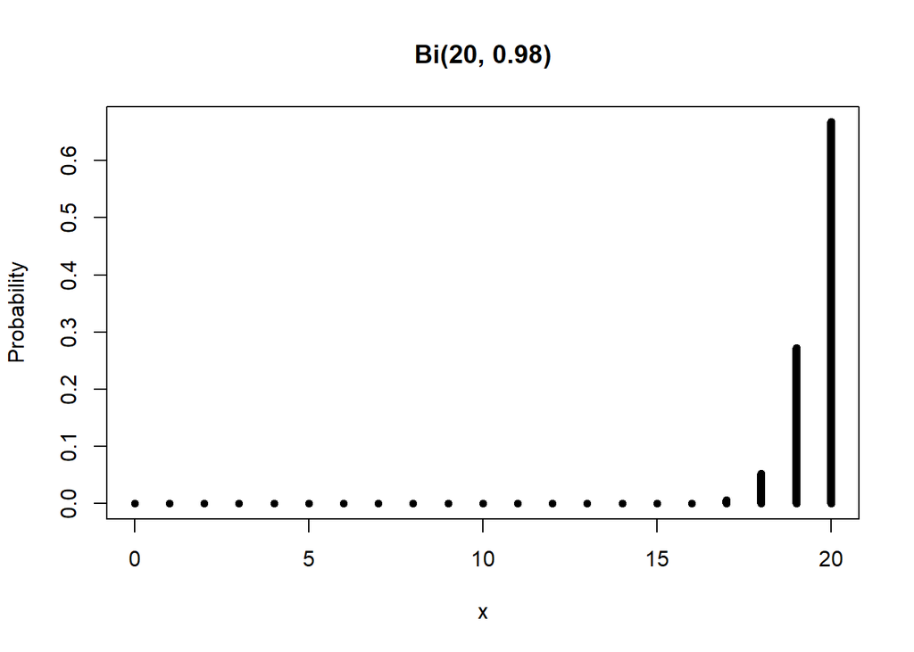

```r
plot(x=x,
     y=prob,
     type='h',
     lwd=6,
     ylab='Probability',
     main='Bi(20, 0.98)'
)
```

## Упражнение 2 (10.10.2023)

```r
library(distr) # for the 'AbscontDistribution' function
library(distrEx) # for E(X) and var(X)
library(readxl) # for read_excel
library(BSDA) # for z.test()
```

### Задача 1

Let X have PDF f(x) = 3x^2, 0 < x < 1 and find P(0.14 < X < 0.71)

```r
f <- function(x) {
  3 * x^2
}
```

```r
integrate(f, lower=0.14, upper=0.71)
```

```
## 0.355167 with absolute error < 3.9e-15
```

```r
X <- AbscontDistribution(d=f, low1=0, up1=1)
```

```r
E(X); var(X)
```

```
## [1] 0.7496337
```

```
## [1] 0.03768305
```

### Задача 2

Suppose in a mathematics quiz there are 30 participants. A question is given to all 30 participants, and the time allowed to answer it is 25 seconds. Find the probability of a random participant responding within 6 seconds?

```r
punif(6, min=0, max=25)
```

```
## [1] 0.24
```

### Задача 3

Suppose a fight is about to land and the announcement says that the expected time for the plane to will definitely land is in the next 30 minutes. What is the average time before the fight lands? Find the probability of getting the fight landing between 25 and 30 minutes and between 10 and 20 minutes using R.

```r
qunif(0.5, min=0, max=30)
```

```
## [1] 15
```

```r
punif(30, 0, 30) - punif(25, 0, 30); punif(25, 0, 30, lower.tail=FALSE)
```

```
## [1] 0.1666667
```

```
## [1] 0.1666667
```

```r
punif(20, 0, 30) - punif(10, 0, 30)
```

```
## [1] 0.3333333
```

### Задача 4

Assume we have a uniform distribution with density f(x) = 1/23, 0 <= x <= 23, X is U(0, 23). Determine the 90th percentile and generate 3 random numbers from the distribution.

```r
qunif(0.9, 0, 23)
```

```
## [1] 20.7
```

```r
runif(3, 0, 23)
```

```
## [1] 15.99858 11.56949 14.47717
```

### Задача 5

```r
pnorm(9, mean=10, sd=2)
```

```
## [1] 0.3085375
```

```r
pnorm(11, mean=10, sd=2, lower.tail=FALSE)
```

```
## [1] 0.3085375
```

```r
pnorm(11, 10, 2) - pnorm(9, 10, 2)
```

```
## [1] 0.3829249
```

```r
qnorm(0.9, 10, 2); qnorm(0.9, 10, 2)
```

```
## [1] 12.5631
```

```
## [1] 12.5631
```

```r
pnorm(12, 10, 2) - pnorm(8, 10, 2)
```

```
## [1] 0.6826895
```

```r
pnorm(14, 10, 2) - pnorm(6, 10, 2)
```

```
## [1] 0.9544997
```

```r
pnorm(16, 10, 2) - pnorm(4, 10, 2)
```

```
## [1] 0.9973002
```

### Задача 6

A toy manufacturer undertakes regular assessment of employee performance. This performance testing consists of measuring the number of a toys that employees can make per hour, with the historical data recording a rate of 85$ per hour with a standard deviation of 15 units. All new employees are tested after a period of training. A new employee is tested on 45 separate random occasions and found to have an output given in the data file *toy_manufacturer.xlsx*. Does this indicate that the new employee’s output is significantly different from the average output? Test at the 5% significance level.

```r
toys <- read_xlsx('toy_manufacturer.xlsx')
toys
```

| ID | Sample data |
| --- | --- |
| 1 | 88.6 |
| 2 | 63.8 |
| 3 | 95.6 |
| 4 | 94.4 |
| 5 | 118.2 |
| 6 | 84.4 |
| 7 | 81.6 |
| 8 | 78.6 |
| 9 | 56.6 |
| 10 | 77.8 |

[output cut: 35 more lines]

```r
bar_X <- mean(toys$`Sample data`)
bar_X
```

```
## [1] 88.74
```

```r
sigma <- 15
n <- length(toys$`Sample data`)
mu_0 <- 85

z <- (bar_X - mu_0) / (sigma/sqrt(n))
z
```

```
## [1] 1.672579
```

```r
p_value <- 2 * (1 - pnorm(1.67))
p_value
```

```
## [1] 0.09491936
```

```r
z.test(toys$`Sample data`, mu=85, sigma.x=15, conf.level=0.95)
```

```
##
##  One-sample z-Test
##
## data:  toys$`Sample data`
## z = 1.6726, p-value = 0.09441
## alternative hypothesis: true mean is not equal to 85
## 95 percent confidence interval:
##  84.35739 93.12261
## sample estimates:
## mean of x
##     88.74
```

We fail to reject the null hypothesis.